# Big Data Science - Assignment 2

EEG Analysis

Arnau Casanova & Alex Flores

2018-04-05

PCA Load the dataset

```r
library(data.table)
library(magrittr)
mydata<-read.table("C:/Users/Arnau/Documents/BigDataScience/assignment1/bigTable.txt", header=TRUE )
```

Check available variables (predictors)

```r
colnames(mydata)
```

```
 [1] "USER"     "STATE"    "EXP_TYPE" "FP1"      "FP2"      "F7"       "F8"
 [8] "AF1"      "AF2"      "FZ"       "F4"       "F3"       "FC6"      "FC5"
[15] "FC2"      "FC1"      "T8"       "T7"       "CZ"       "C3"       "C4"
[22] "CP5"      "CP6"      "CP1"      "CP2"      "P3"       "P4"       "PZ"
[29] "P8"       "P7"       "PO2"      "PO1"      "O2"       "O1"       "X"
[36] "AF7"      "AF8"      "F5"       "F6"       "FT7"      "FT8"      "FPZ"
[43] "FC4"      "FC3"      "C6"       "C5"       "F2"       "F1"       "TP8"
[50] "TP7"      "AFZ"      "CP3"      "CP4"      "P5"       "P6"       "C1"
[57] "C2"       "PO7"      "PO8"      "FCZ"      "POZ"      "OZ"       "P2"
[64] "P1"       "CPZ"      "nd"       "Y"
```

Take a look at the structure

```r
mydata$STATE <-as.factor(mydata$STATE)
str(mydata)
```

```
'data.frame':   1729 obs. of  67 variables:
 $ USER    : Factor w/ 20 levels "co2a0000424",..: 1 1 1 1 1 1 1 1 1 1 ...
 $ STATE   : Factor w/ 2 levels "0","1": 2 2 2 2 2 2 2 2 2 2 ...
 $ EXP_TYPE: Factor w/ 5 levels "S1obj","S2match",..: 1 1 2 4 1 4 2 2 4 1 ...
 $ FP1     : num  -3.07 5.82 -1.84 -2.36 5.67 ...
 $ FP2     : num  -0.729 8.756 -0.301 0.747 7.842 ...
 $ F7      : num  -6.706 2.026 1.367 -0.373 0.907 ...
 $ F8      : num  -0.339 5.676 0.03 1.242 3.77 ...
 $ AF1     : num  -5.15 3.05 -2.59 -2.54 2.43 ...
 $ AF2     : num  -2.938 4.031 -1.216 0.943 3.673 ...
 $ FZ      : num  -4.364 1.4 -2.5 0.098 1.365 ...
 $ F4      : num  -4.053 3.204 -0.088 2.732 0.588 ...
 $ F3      : num  -5.329 -0.016 -0.9 -1.373 0.325 ...
 $ FC6     : num  -1.587 2.483 -0.257 2.413 -0.241 ...
 $ FC5     : num  -6.735 -2.801 0.613 -0.755 -2.111 ...
```

[output cut: 53 more lines]

Conversion of categorical variables

```r
#Convert categorical variables
library(dummies)
new_my_data <- dummy.data.frame(mydata, names = c("USER", "STATE", "EXP_TYPE"))
str(new_my_data)
```

```
'data.frame':   1729 obs. of  91 variables:
 $ USERco2a0000424     : int  1 1 1 1 1 1 1 1 1 1 ...
 $ USERco2a0000425     : int  0 0 0 0 0 0 0 0 0 0 ...
 $ USERco2a0000426     : int  0 0 0 0 0 0 0 0 0 0 ...
 $ USERco2a0000427     : int  0 0 0 0 0 0 0 0 0 0 ...
 $ USERco2a0000428     : int  0 0 0 0 0 0 0 0 0 0 ...
 $ USERco2a0000429     : int  0 0 0 0 0 0 0 0 0 0 ...
 $ USERco2a0000430     : int  0 0 0 0 0 0 0 0 0 0 ...
 $ USERco2a0000432     : int  0 0 0 0 0 0 0 0 0 0 ...
 $ USERco2a0000433     : int  0 0 0 0 0 0 0 0 0 0 ...
 $ USERco2a0000447     : int  0 0 0 0 0 0 0 0 0 0 ...
 $ USERco2c0000337     : int  0 0 0 0 0 0 0 0 0 0 ...
 $ USERco2c0000338     : int  0 0 0 0 0 0 0 0 0 0 ...
 $ USERco2c0000339     : int  0 0 0 0 0 0 0 0 0 0 ...
 $ USERco2c0000340     : int  0 0 0 0 0 0 0 0 0 0 ...
```

[output cut: 81 more lines]

PCA

```r
prin_comp <- prcomp(new_my_data, scale. = T)
names(prin_comp)
```

```
[1] "sdev"     "rotation" "center"   "scale"    "x"
```

Mean and sd of variables

```r
prin_comp$center
```

```
     USERco2a0000424      USERco2a0000425      USERco2a0000426      USERco2a0000427
         0.058415269          0.017351070          0.040485830          0.050896472
     USERco2a0000428      USERco2a0000429      USERco2a0000430      USERco2a0000432
         0.045691151          0.034123771          0.061885483          0.060150376
     USERco2a0000433      USERco2a0000447      USERco2c0000337      USERco2c0000338
         0.046269520          0.052631579          0.045112782          0.059572007
     USERco2c0000339      USERco2c0000340      USERco2c0000341      USERco2c0000342
         0.046847889          0.047426258          0.056680162          0.065934066
     USERco2c0000344      USERco2c0000345      USERco2c0000395      USERco2c0000396
         0.053209948          0.064198959          0.060150376          0.032967033
              STATE0               STATE1        EXP_TYPES1obj      EXP_TYPES2match
         0.532099479          0.467900521          0.506072874          0.244071718
  EXP_TYPES2matcherr    EXP_TYPES2nomatch EXP_TYPES2nomatcherr                  FP1
         0.008097166          0.238288028          0.003470214         -0.265764604
                 FP2                   F7                   F8                  AF1
        -0.163554656         -0.978689994         -0.277358010         -0.603625217
                 AF2                   FZ                   F4                   F3
        -0.606277039         -0.882264315         -0.439779063         -0.656983806
                 FC6                  FC5                  FC2                  FC1
        -0.339285136         -0.826207056         -0.452731058         -0.539175246
                  T8                   T7                   CZ                   C3
        -0.765515905         -1.190094274         -3.553094853         -0.381432042
                  C4                  CP5                  CP6                  CP1
        -0.196829960         -0.724574320         -0.676637941          0.073143436
                 CP2                   P3                   P4                   PZ
         0.052253904         -0.590536726         -0.563124928         -0.038054367
                  P8                   P7                  PO2                  PO1
        -1.793955466         -1.668139965         -1.414582996         -1.260304222
                  O2                   O1                    X                  AF7
        -2.409114517         -2.350983806          0.128680162         -0.428290341
                 AF8                   F5                   F6                  FT7
        -0.005933488         -0.624382880         -0.352211683         -1.157532099
                 FT8                  FPZ                  FC4                  FC3
        -0.648866397         -0.403722383         -0.312555234         -0.562117409
                  C6                   C5                   F2                   F1
        -0.373255061         -0.706097744         -0.646377675         -0.754584153
                 TP8                  TP7                  AFZ                  CP3
        -1.102626952         -1.236581839         -0.768453441         -0.217621747
                 CP4                   P5                   P6                   C1
        -0.132161365         -1.016391556         -1.195323887         -0.202111625
                  C2                  PO7                  PO8                  FCZ
        -0.097063042         -2.089366108         -2.512529208         -0.621513592
                 POZ                   OZ                   P2                   P1
        -1.182468479         -2.250566802         -0.418666859         -0.204811452
                 CPZ                   nd                    Y
         0.182093696         -0.705057259         -1.558754772
```

```r
prin_comp$scale
```

```
     USERco2a0000424      USERco2a0000425      USERco2a0000426      USERco2a0000427
          0.23459488           0.13061347           0.19715275           0.21984989
     USERco2a0000428      USERco2a0000429      USERco2a0000430      USERco2a0000432
          0.20887485           0.18159960           0.24101715           0.23783403
     USERco2a0000433      USERco2a0000447      USERco2c0000337      USERco2c0000338
          0.21012898           0.22336148           0.20761153           0.23676065
     USERco2c0000339      USERco2c0000340      USERco2c0000341      USERco2c0000342
          0.21137409           0.21261033           0.23129735           0.24823861
     USERco2c0000344      USERco2c0000345      USERco2c0000395      USERco2c0000396
          0.22451682           0.24517793           0.23783403           0.17860195
              STATE0               STATE1        EXP_TYPES1obj      EXP_TYPES2match
          0.49911292           0.49911292           0.50010776           0.42965973
  EXP_TYPES2matcherr    EXP_TYPES2nomatch EXP_TYPES2nomatcherr                  FP1
          0.08964513           0.42615946           0.05882323           9.62477220
                 FP2                   F7                   F8                  AF1
          9.04454982           7.25888955           9.11403702           7.29764369
                 AF2                   FZ                   F4                   F3
          6.61239015           6.70054547           5.29972641           5.03324389
                 FC6                  FC5                  FC2                  FC1
          4.80248466           5.12255198           3.65032722           3.48267846
                  T8                   T7                   CZ                   C3
          5.67187123           5.59500842          19.58823179           3.29343858
                  C4                  CP5                  CP6                  CP1
          3.35479606           4.68900969           4.78826062           3.08202945
                 CP2                   P3                   P4                   PZ
          3.13849127           4.89229047           5.08035245           5.01587238
                  P8                   P7                  PO2                  PO1
          6.13943075           6.32565134           7.03005019           5.88681689
                  O2                   O1                    X                  AF7
          7.52194543           6.85752954          15.07877424           8.74809012
                 AF8                   F5                   F6                  FT7
          8.65988612           5.91204277           5.95015842           6.33173420
                 FT8                  FPZ                  FC4                  FC3
          6.31830892           9.94913851           4.12286347           4.10617389
                  C6                   C5                   F2                   F1
          4.57439522           4.94095756           5.15617538           5.12509202
                 TP8                  TP7                  AFZ                  CP3
          5.71436949           5.76750711           6.35340140           3.89719128
                 CP4                   P5                   P6                   C1
          3.60988816           5.33408456           5.23776844           2.92516845
                  C2                  PO7                  PO8                  FCZ
          2.88170258           6.32689436           7.02889994           3.59535145
                 POZ                   OZ                   P2                   P1
          5.80519846           6.83661661           4.67703051           4.75052525
                 CPZ                   nd                    Y
          3.34408802           8.75039379           9.69334451
```

```r
prin_comp$rotation
```

```
                               PC1           PC2           PC3           PC4          PC5
USERco2a0000424      -0.0054595042  1.440281e-02 -1.775084e-02  0.0652459471 -0.142663883
USERco2a0000425      -0.0073138200 -3.160971e-02 -1.290221e-02  0.0353091152 -0.084678702
USERco2a0000426      -0.0143863606  5.714311e-03  5.582739e-03  0.0876571432 -0.081400402
USERco2a0000427      -0.0115264205  7.821917e-03 -1.402748e-02  0.1268486570 -0.063396974
USERco2a0000428      -0.0042183927  3.794833e-03 -3.619758e-02  0.0984635764 -0.077125363
USERco2a0000429      -0.0067144454 -4.279859e-02  2.441061e-02  0.0624783074 -0.098040668
USERco2a0000430      -0.0025518285  2.754938e-02 -1.277056e-02  0.1061074105 -0.120348948
USERco2a0000432       0.0004108407  7.277888e-03 -1.207792e-02  0.1187867767 -0.098481080
USERco2a0000433      -0.0008794976 -4.471048e-04  4.243651e-02  0.1161909296 -0.083626650
USERco2a0000447      -0.0017549966 -6.732494e-04 -2.004602e-02  0.0870783449 -0.106872831
                               PC6          PC7           PC8           PC9          PC10
USERco2a0000424       0.0408193581 -0.066044127  0.0466320221 -1.926551e-02  0.1338832484
USERco2a0000425      -0.0808261274 -0.064907688 -0.0133674552 -4.276198e-02 -0.0615507817
USERco2a0000426      -0.0062737732 -0.064441945 -0.0022037450  9.960688e-02 -0.1328779822
USERco2a0000427       0.0129154964  0.048508191 -0.0743174749 -4.180522e-02  0.1885963052
USERco2a0000428       0.1731338554 -0.098327282 -0.0637372208 -5.464293e-02 -0.0733283644
USERco2a0000429      -0.0549627590  0.011689644  0.0926921172  3.702593e-02  0.1169755401
USERco2a0000430      -0.0496215923  0.068132811 -0.2195576607  2.382276e-02  0.1352112296
USERco2a0000432       0.0503835172  0.026469472  0.0784522210  5.409353e-04 -0.1667601125
USERco2a0000433      -0.0924546157  0.194618365  0.1875685029  1.565187e-01 -0.3070399154
USERco2a0000447       0.0907155145 -0.065409718  0.0589714977 -1.447502e-01  0.1783519333
                             PC11         PC12          PC13          PC14          PC15
USERco2a0000424      -0.143822940  0.116261779 -0.1921251746  0.0918088027 -1.955529e-02
USERco2a0000425      -0.001557409  0.213327483  0.2728621477  0.3492537687 -7.200605e-02
USERco2a0000426      -0.034353065 -0.126587649 -0.0162218089  0.1049575859 -1.603761e-01
USERco2a0000427      -0.065626764  0.003169286 -0.0853306870  0.0191351734  3.365542e-01
USERco2a0000428       0.024801656 -0.083378245  0.3427487863 -0.0514172568 -1.959405e-01
USERco2a0000429       0.313282700 -0.059971828 -0.0724739851 -0.1677823159  4.843443e-02
USERco2a0000430       0.317385457  0.162655742 -0.1261046279 -0.0405222762 -2.908243e-01
USERco2a0000432      -0.169730793 -0.020153889 -0.1946805519  0.1713918774 -2.010882e-02
USERco2a0000433      -0.109881072 -0.141104650  0.2882287670 -0.2084258352  1.624881e-01
USERco2a0000447      -0.060817868 -0.039969191 -0.0694803484 -0.1901003299  1.902494e-01
                             PC16          PC17         PC18         PC19          PC20
USERco2a0000424      -0.586587849  0.3360480216  0.087637996  0.260293911 -0.2455233830
USERco2a0000425       0.160318066  0.0016652833 -0.053683457  0.118662258 -0.0715729266
USERco2a0000426       0.070906415 -0.0362817512 -0.222293304 -0.270424502  0.2477390903
USERco2a0000427       0.043833090  0.1569798661 -0.201588432  0.185050632  0.3725159909
USERco2a0000428      -0.032455319  0.1270326381 -0.160143321  0.118578183  0.2438978330
USERco2a0000429      -0.119834958  0.0631627297 -0.024432181 -0.148144845  0.2382933224
```

[output cut: 155 more lines]

```
USERco2a0000432       0.0005116862 -1.160795e-02  3.207827e-01  3.005951e-02  9.476796e-03
USERco2a0000433       0.0054081035 -1.036264e-02  2.834151e-01  2.655791e-02  8.372854e-03
USERco2a0000447       0.0091682465 -1.020488e-02  3.012626e-01  2.823035e-02  8.900120e-03
                              PC91
USERco2a0000424       0.000000e+00
USERco2a0000425       2.584738e-16
USERco2a0000426      -1.361612e-16
USERco2a0000427       4.065588e-16
USERco2a0000428      -1.379918e-16
USERco2a0000429      -3.516405e-16
USERco2a0000430      -3.161167e-17
USERco2a0000432       2.998624e-16
USERco2a0000433      -7.164567e-17
USERco2a0000447      -7.228211e-17
 [ reached getOption("max.print") -- omitted 81 rows ]
```

Principal component score vectors in 1729x91 dimension

```r
dim(prin_comp$x)
```

```
[1] 1729   91
```

Plot the resultant principal compoents

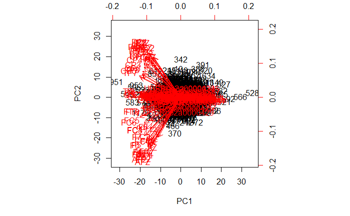

```r
biplot(prin_comp, scale = 0)
```

Standard deviation of each principal compoent

```r
std_dev <- prin_comp$sdev
```

Variance

```r
pr_var <- std_dev^2
```

Check variance of first 10 components, higher value higher will be the information of these components

```r
pr_var[1:10]
```

```
 [1] 29.110748 13.955469  3.714668  3.122660  3.027678  1.912030  1.518128  1.429381
 [9]  1.330068  1.216672
```

Compute the proportion of variance explained by each component. Divide variance by sum total variance:

```r
prop_varex <- pr_var/sum(pr_var)
prop_varex[1:20]
```

```
 [1] 0.31989833 0.15335680 0.04082053 0.03431495 0.03327118 0.02101132 0.01668272
 [8] 0.01570748 0.01461613 0.01337003 0.01293764 0.01247504 0.01232764 0.01211606
[15] 0.01181891 0.01178630 0.01174337 0.01171469 0.01167359 0.01159248
```

1st component 31.9%, 2nd 15.33% and so on. How many components for the modeling? use scree plot to se variability in the data.

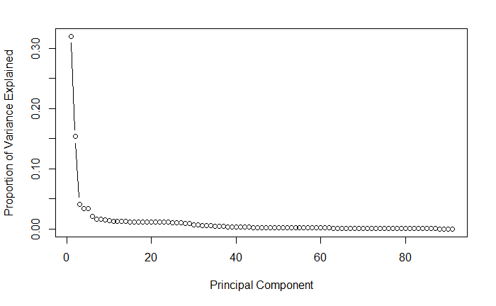

```r
#scree plot
plot(prop_varex, xlab = "Principal Component",
             ylab = "Proportion of Variance Explained",
             type = "b")
```

```r
sum(pr_var[1:30])
```

```
[1] 80.51112
```

Check the cumulative variance plot to see number of components

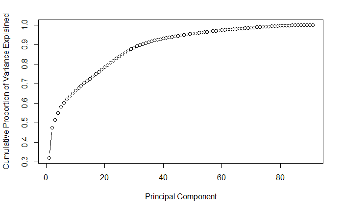

```r
#cumulative scree plot
plot(cumsum(prop_varex), xlab = "Principal Component",
              ylab = "Cumulative Proportion of Variance Explained",
              type = "b")
```

We see that 30 components resulta a variance close to 90%

Use the 30 components

```r
data2 <- data.frame(Alcoholic = mydata$STATE, prin_comp$x)
#1st 30 PCAs
data2 <- data2[,1:31]
#decision tree
library(rpart)
rpart.model <- rpart(Alcoholic ~ .,data = data2, method = "anova")
rpart.model
```

```
n= 1729

node), split, n, deviance, yval
      * denotes terminal node

 1) root 1729 430.4685000 1.467901
   2) PC5>=-0.1659645 915 107.1956000 1.135519
     4) PC4< 1.776249 784   0.9987245 1.001276 *
     5) PC4>=1.776249 131   7.5114500 1.938931
      10) PC5>=2.773652 8   0.0000000 1.000000 *
      11) PC5< 2.773652 123   0.0000000 2.000000 *
   3) PC5< -0.1659645 814 108.5565000 1.841523
     6) PC4< -2.093687 133   4.8120300 1.037594 *
     7) PC4>=-2.093687 681   0.9985316 1.998532 *
```

```r
#transform tests into PCA
test.data <- predict(prin_comp, newdata = new_my_data)
test.data <- as.data.frame(test.data)
#30 components
test.data <- test.data[,1:30]
rpart.prediction <- predict(rpart.model, test.data)
```

Logistic regresion: Data modification, calculate the mean of every row. It will be the explicative variable and STATE will be the answer (factor). That’s X and Y.

```r
mydata.lr <-  mydata[2]
mydata.lr[2] <- c("0")
names (mydata.lr)[2] <- c("MEAN")
mydatanumeric <- mydata
mydatanumeric$USER <- NULL
mydatanumeric$STATE <- NULL
mydatanumeric$EXP_TYPE<- NULL
mymeans <- apply(mydatanumeric, 1, mean)
## filling the dataset with the MEAN values
for (i in 1:1729){
  mydata.lr[i,2] <- mymeans[i]
}
plot(mydata.lr$MEAN, jitter(mydata.lr$STATE, 0.15), pch = 19, xlab = "Means", ylab ="Alcoholic (0 - non, 1 - alcoholic)")
```

```
Error in jitter(mydata.lr$STATE, 0.15) : 'x' must be numeric
```